# Machine Learning Assignment

JAGU

7 mei 2017

# SYNOPSIS.

## 6 participants with accelerometers on belt, forearm, arm, and a dumb-bell. They were asked to perform barbell lifts correctly and incorrectly, in 5 different ways. People regularly quantify how much of a particular activity they do, but they rarely quantify how well they do it. Given a dataset with dimension 19622X160 and the -classe- variable with the classifications A,B,C,D and E. Goal is to predict the classifications of how well the exercises were performed by the 6 participants.Data was available on:http://groupware.les.inf.puc-rio.br/har

### MODEL ASSESSMENT.

#### 2 main requirements for the model are needed. It should perform classification and capable of handling NA values. There are a number of algoritms that can handle NA-values. All working with na.omit. For now I only know randomForest can work with na.roughfix and rpart with na.rpart. RandomForest however can not handle large factor variables. Na.omit can be used with not to many NA’s. As can be seen below from the 19622 observations only 406 observations are left free of NA’s.

```r
library(rpart);library(stringr)
pml=read.csv("pml-training.csv",header=TRUE)
dim(pml)
```

```
## [1] 19622   160
```

```r
pmlClean=na.omit(pml); dim(pmlClean)
```

```
## [1] 406 160
```

#### Rpart with na.rpart is the only algorithm that can work on any subset of the original data, without preprocessing. A random subset of 1000 observation is taken as the Probe set, from the original training set of 19622 observations.

```r
set.seed(200)
train=sample(nrow(pml),1000)
training=pml[train,]
set.seed(93931)
train1=sample(nrow(pml),20)
testing=pml[train1,]
```

#### Fitting rpart on the training set. Rpart uses default 10-Fold Cross Validation.The number of folds can be changed in the -xval- parameter.

```r
set.seed(200)
fitRpart<-rpart(classe ~.,data=training,na.action=na.rpart)
```

#### For prediction the pml-testing data are read into R and used for prediction.

```r
pmlTest<-read.csv("pml-testing.csv",header=TRUE)
#predTest<-predict(fitRpart,pmlTest)
```

#### This gives an error. A dataframe is stored on disk as a file, a character string. Where observations are lines and variables are fields of a line. By importing in R, the file is converted to a dataframe, and a class is assigned to the character fields. Due to the values in those fields, these classes can be different from the original classes. Read.csv put also double quotes on factor variables, which has to be removed for prediction. The names too are changed, get a prefix, and have to be converted back to the original. This and that can be seen here.

```r
pmlTest<-read.csv("pml-testing.csv",header=TRUE,quote=NULL)
str(pmlTest[1:6,1:8])
```

```
## 'data.frame':    6 obs. of  8 variables:
##  $ X..                    : Factor w/ 20 levels "\"1\"","\"10\"",..: 1 12 14 15 16 17
##  $ X.user_name.           : Factor w/ 6 levels "\"adelmo\"","\"carlitos\"",..: 6 5 5 1 4 5
##  $ X.raw_timestamp_part_1.: int  1323095002 1322673067 1322673075 1322832789 1322489635 1322673149
##  $ X.raw_timestamp_part_2.: int  868349 778725 342967 560311 814776 510661
##  $ X.cvtd_timestamp.      : Factor w/ 11 levels "\"02/12/2011 13:33\"",..: 5 10 10 1 6 11
##  $ X.new_window.          : Factor w/ 1 level "\"no\"": 1 1 1 1 1 1
##  $ X.num_window.          : int  74 431 439 194 235 504
##  $ X.roll_belt.           : num  123 1.02 0.87 125 1.35 -5.92
```

#### Removing these quotes from factor variables.

```r
for(i in 1: ncol(pmlTest)){
  if(class(pmlTest[,i])=="factor"){
    pmlTest[,i]<-str_replace_all(pmlTest[,i],"\"","");
    pmlTest[,i]<-as.factor(pmlTest[,i])}
}
str(pmlTest[1:5,1:8])
```

```
## 'data.frame':    5 obs. of  8 variables:
##  $ X..                    : Factor w/ 20 levels "1","10","11",..: 1 12 14 15 16
##  $ X.user_name.           : Factor w/ 6 levels "adelmo","carlitos",..: 6 5 5 1 4
##  $ X.raw_timestamp_part_1.: int  1323095002 1322673067 1322673075 1322832789 1322489635
##  $ X.raw_timestamp_part_2.: int  868349 778725 342967 560311 814776
##  $ X.cvtd_timestamp.      : Factor w/ 11 levels "02/12/2011 13:33",..: 5 10 10 1 6
##  $ X.new_window.          : Factor w/ 1 level "no": 1 1 1 1 1
##  $ X.num_window.          : int  74 431 439 194 235
##  $ X.roll_belt.           : num  123 1.02 0.87 125 1.35
```

#### Assign the same classes and names to the test-set as in the Probe training set.

```r
names(pmlTest)<-names(training)
for(i in 1:ncol(pmlTest)){class(pmlTest[,i])<-class(training[,i])}
str(pmlTest[1:6,1:12]);str(training[1:6,1:12])
```

```
## 'data.frame':    6 obs. of  12 variables:
##  $ X                   : int  1 12 14 15 16 17
##  $ user_name           : Factor w/ 6 levels "adelmo","carlitos",..: 6 5 5 1 4 5
##  $ raw_timestamp_part_1: int  1323095002 1322673067 1322673075 1322832789 1322489635 1322673149
##  $ raw_timestamp_part_2: int  868349 778725 342967 560311 814776 510661
##  $ cvtd_timestamp      : Factor w/ 11 levels "02/12/2011 13:33",..: 5 10 10 1 6 11
##  $ new_window          : Factor w/ 1 level "no": 1 1 1 1 1 1
##  $ num_window          : int  74 431 439 194 235 504
##  $ roll_belt           : num  123 1.02 0.87 125 1.35 -5.92
##  $ pitch_belt          : num  27 4.87 1.82 -41.6 3.33 1.59
##  $ yaw_belt            : num  -4.75 -88.9 -88.5 162 -88.6 -87.7
##  $ total_accel_belt    : int  20 4 5 17 3 4
##  $ kurtosis_roll_belt  : Factor w/ 1 level "": 1 1 1 1 1 1
```

```
## 'data.frame':    6 obs. of  12 variables:
##  $ X                   : int  10474 11455 11568 13558 13092 16465
##  $ user_name           : Factor w/ 6 levels "adelmo","carlitos",..: 2 1 1 3 6 2
##  $ raw_timestamp_part_1: int  1323084306 1322832873 1322832878 1322837928 1323095048 1323084343
##  $ raw_timestamp_part_2: int  736361 236305 936330 652298 408339 920334
##  $ cvtd_timestamp      : Factor w/ 20 levels "02/12/2011 13:32",..: 11 3 3 7 14 11
##  $ new_window          : Factor w/ 2 levels "no","yes": 1 1 1 1 1 1
##  $ num_window          : int  378 550 554 140 113 35
##  $ roll_belt           : num  1.46 127 127 119 121 7.55
##  $ pitch_belt          : num  6.82 -40.8 -41.2 16.9 25.7 3.6
##  $ yaw_belt            : num  -92.9 161 161 0.13 -6.65 -91.3
##  $ total_accel_belt    : int  3 18 18 18 19 1
##  $ kurtosis_roll_belt  : Factor w/ 397 levels "","-0.016850",..: 1 1 1 1 1 1
```

```r
fitRpart<-rpart(classe ~.,training,na.action=na.rpart)
predRpart=predict(fitRpart,pmlTest)
```

#### Convert the predictions to the classifications A,B,C,D and E.

```r
predRpart<-as.data.frame(predRpart)
wb<-which(predRpart$B==1) #wb= which indices with a B reading.
predRpart[wb,"B"]=2
wc<-which(predRpart$C==1)
predRpart[wc,"C"]=3
wd<-which(predRpart$D==1)
predRpart[wd,"D"]=4
we<-which(predRpart$E==1)
predRpart[we,"E"]=5
#Make 1-dim Resultvector with classifications
result<-vector()
p<-predRpart
for (i in 1: nrow(p)){
   if (sum(p[i,])==1){result[i]<-"A"}
   if (sum(p[i,])==2){result[i]<-"B"}
   if (sum(p[i,])==3){result[i]<-"C"}
   if (sum(p[i,])==4){result[i]<-"D"}
   if (sum(p[i,])==5){result[i]<-"E"}
}
```

#### The predicted Result is;

```r
print(result)
```

```
##  [1] "A" "A" "A" "A" "A" "A" "A" "A" "A" "A" "A" "A" "A" "A" "A" "A" "A"
## [18] "A" "A" "A"
```

### Model Selection.

```
##
## Classification tree:
## rpart(formula = classe ~ ., data = training, na.action = na.rpart)
##
## Variables actually used in tree construction:
## [1] X
##
## Root node error: 729/1000 = 0.729
##
## n= 1000
##
##        CP nsplit rel error    xerror      xstd
## 1 0.27846      0   1.00000 1.0000000 0.0192806
## 2 0.26612      1   0.72154 0.7572016 0.0215715
## 3 0.23457      2   0.45542 0.4567901 0.0204436
## 4 0.22085      3   0.22085 0.2757202 0.0173838
## 5 0.01000      4   0.00000 0.0013717 0.0013711
```

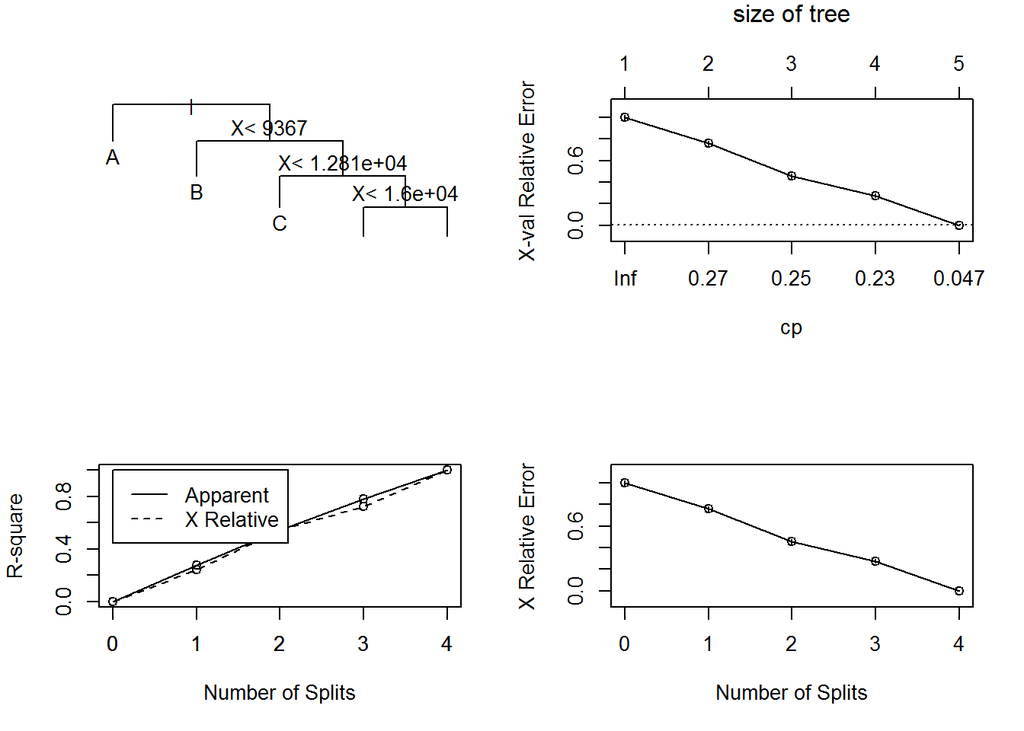

```r
par(mfrow=c(2,2))
plot(fitRpart);text(fitRpart)
plotcp(fitRpart, minline = TRUE, lty = 3, col = 1, upper = c("size", "splits", "none"))
rsq.rpart(fitRpart)
```